# M2_991_20242_PAC4_mdicheva

[figure not shown]

M2.991 · Aprenentatge automàtic · PAC4

2024-2 · Màster universitari en Ciència de dades (Data science)

Estudis d'Informàtica, Multimèdia i Telecomunicació

# **PAC 4: Combinació de Models**

## Objectiu

Aquesta quarta Pràctica d'Avaluació Contínua (PAC 4) té com a objectiu principal consolidar els coneixements adquirits a les PAC anteriors (introducció a l'aprenentatge automàtic, anàlisi exploratòria de dades, mètodes supervisats i no supervisats) i introduir i aprofundir en tècniques avançades d'Ensemble Learning (Aprenentatge per Conjunts).

En finalitzar aquesta PAC, hauries de ser capaç de:

- Implementar i comparar diverses tècniques d'ensemble learning (p. ex., Bagging/Random Forest, Boosting -AdaBoost, Gradient Boosting-, i Stacking) sobre un conjunt de dades específic.
- Analitzar i explicar com els hiperparàmetres clau dels mètodes ensemble influeixen en el seu comportament i rendiment.
- Avaluar i comparar la importància de les característiques (feature importance) obtinguda a través de diferents models ensemble.
- Justificar quan i per què un mètode ensemble podria ser preferible a un altre, o a un model individual (connectant amb conceptes com el trade-off biaix-variància).
- Aplicar correctament metodologies de validació (com la validació creuada) per a l'avaluació i comparació robusta dels models ensemble.

## Conjunt de dades

Treballaràs amb dos conjunts de dades sintètics, generats específicament per a aquesta pràctica: un per a un problema de classificació multiclase i un altre per a un problema de regressió. Ambdós datasets han estat dissenyats per incloure diverses complexitats (com desequilibri de classes, relacions no lineals, interaccions entre variables, soroll, variables irrellevants, etc.) que posaran a prova les capacitats de diferents algorismes.

L'objectiu no és només implementar els algorismes, sinó sobretot analitzar en profunditat el seu comportament, comparar els seus resultats i justificar les teves conclusions basant-te sempre en l'evidència obtinguda dels teus propis experiments i resultats numèrics/gràfics. Es valorarà especialment la capacitat crítica i la profunditat de les teves interpretacions.

```python
import pandas as pd
import numpy as np
import matplotlib.pyplot as plt
import seaborn as sns
from sklearn.model_selection import train_test_split
from sklearn.linear_model import LogisticRegression
from sklearn.tree import DecisionTreeClassifier
from sklearn.neighbors import KNeighborsClassifier
from sklearn.naive_bayes import GaussianNB
from sklearn.metrics import classification_report, confusion_matrix, f1_score
from sklearn.preprocessing import StandardScaler
from sklearn.ensemble import RandomForestClassifier
from sklearn.model_selection import GridSearchCV
from sklearn.ensemble import GradientBoostingClassifier
from sklearn.ensemble import StackingClassifier
from sklearn.linear_model import LinearRegression
from sklearn.tree import DecisionTreeRegressor
from sklearn.model_selection import cross_val_score, cross_val_predict, KFold
from sklearn.metrics import mean_squared_error, mean_absolute_error, r2_score
from sklearn.ensemble import RandomForestRegressor
from sklearn.metrics import make_scorer, mean_squared_error
```

**Nom i cognoms: Maggi Dicheva Baeva**

## 1. Combinació de models de Classificació (6 punts)

### 1.1. Càrrega i Anàlisi Exploratòria de Dades -EDA- (0.5 punts)

#### Implementació:

1. Carrega el dataset `dataset_clasificacion_pec4.csv`.
2. Realitza una exploració inicial: revisa la informació general, identifica els tipus de dades, valors mancants, outliers, anàlisi de correlacions, etc.

#### Solució:

```python
df = pd.read_csv("dataset_clasificacion_pec4.csv")
print("Informació general del dataset:")
print(df.info())
```

```
Informació general del dataset:
<class 'pandas.core.frame.DataFrame'>
RangeIndex: 3000 entries, 0 to 2999
Data columns (total 24 columns):
 #   Column      Non-Null Count  Dtype
---  ------      --------------  -----
 0   feature_0   3000 non-null   float64
 1   feature_1   3000 non-null   float64
 2   feature_2   3000 non-null   float64
 3   feature_3   3000 non-null   float64
 4   feature_4   3000 non-null   float64
 5   feature_5   3000 non-null   float64
 6   feature_6   3000 non-null   float64
 7   feature_7   3000 non-null   float64
 8   feature_8   3000 non-null   float64
```

[output cut: 18 more lines]

```python
print("Estadístiques descriptives:")
display(df.describe())
```

```
Estadístiques descriptives:
```

|  | feature_0 | feature_1 | feature_2 | feature_3 | feature_4 | feature_5 | feature_6 | feature_7 | feature_8 | feature_9 | ... | feature_12 | feature_13 | feature_14 | feature_15 | feature_16 | feature_17 | feature_18 | feature_19 | feature_20 | target |
| --- | --- | --- | --- | --- | --- | --- | --- | --- | --- | --- | --- | --- | --- | --- | --- | --- | --- | --- | --- | --- | --- |
| count | 3000.000000 | 3000.000000 | 3000.000000 | 3000.000000 | 3000.000000 | 3000.000000 | 3000.000000 | 3000.000000 | 3000.000000 | 3000.000000 | ... | 3000.000000 | 3000.000000 | 3000.000000 | 3000.000000 | 3000.000000 | 3000.000000 | 3000.000000 | 3000.000000 | 3000.000000 | 3000.000000 |
| mean | -0.167780 | 0.194072 | 0.021713 | 0.565079 | 0.339354 | 0.001514 | 0.214931 | 0.200799 | -0.574093 | 0.019909 | ... | 0.014867 | 0.214931 | 1.260273 | -0.887056 | -0.011400 | 0.832865 | 0.018429 | -0.013065 | -0.019091 | 0.704333 |
| std | 1.992783 | 2.009702 | 1.988687 | 1.997788 | 1.988697 | 1.005382 | 1.905222 | 1.856595 | 1.850820 | 0.989841 | ... | 1.033604 | 1.905222 | 2.845021 | 3.746794 | 1.019393 | 1.750359 | 0.986256 | 1.006372 | 1.400266 | 0.781314 |
| min | -7.430478 | -7.017886 | -6.903463 | -7.177407 | -7.157275 | -3.596199 | -6.640535 | -7.127550 | -7.571720 | -3.278118 | ... | -3.225881 | -6.640535 | -12.132204 | -13.883680 | -3.256573 | -9.801035 | -3.333694 | -3.587773 | -5.427674 | 0.000000 |
| 25% | -1.537541 | -1.085016 | -1.288022 | -0.698250 | -1.032249 | -0.668274 | -1.106546 | -1.020612 | -1.809644 | -0.655480 | ... | -0.667546 | -1.106546 | -0.425860 | -3.300002 | -0.710163 | -0.318462 | -0.662098 | -0.681826 | -0.766254 | 0.000000 |
| 50% | -0.233910 | 0.260095 | 0.042402 | 0.616664 | 0.317372 | -0.006355 | 0.130390 | 0.237213 | -0.666510 | 0.027168 | ... | 0.028628 | 0.130390 | 1.359148 | -0.913211 | -0.011754 | 0.860290 | -0.005160 | -0.030038 | -0.011659 | 1.000000 |
| 75% | 1.121515 | 1.573280 | 1.419595 | 1.849444 | 1.672007 | 0.653912 | 1.446997 | 1.463993 | 0.517805 | 0.695489 | ... | 0.703204 | 1.446997 | 3.089139 | 1.596332 | 0.685768 | 1.964828 | 0.716549 | 0.650218 | 0.687983 | 1.000000 |
| max | 8.853569 | 7.291045 | 6.099481 | 7.803933 | 8.439868 | 4.199419 | 6.973083 | 6.515078 | 7.543879 | 3.684574 | ... | 3.757089 | 6.973083 | 12.814550 | 12.245034 | 3.186992 | 7.863993 | 4.163465 | 3.856838 | 6.772951 | 2.000000 |

8 rows × 22 columns

```python
print("Primeres files del dataset:")
print(df.head())
```

```
Primeres files del dataset:
   feature_0  feature_1  feature_2  feature_3  feature_4  feature_5  \
0   1.821258   0.910395   0.459186  -1.030711   2.098087   1.921148
1   4.229767  -0.434469   4.726087   0.995552  -3.966756   2.444360
2   0.860488   0.984565   0.042947  -0.365520  -4.947303  -0.574780
3   1.503285   1.769841   1.307190   1.309311   1.169251   0.514564
4  -0.019055  -1.569077  -0.824806   2.347602  -1.001121   0.323452

   feature_6  feature_7  feature_8  feature_9  ...  feature_14  feature_15  \
0  -2.657309  -1.737789  -0.491327   0.782738  ...    4.431102    0.699121
1  -3.308983   0.848826   0.707739  -1.066422  ...    0.863514    0.032210
2  -2.312484   2.228463  -0.119455   0.893592  ...   -3.323280   -1.348569
3   0.847147   0.674670  -3.177230  -0.638325  ...    3.293377    0.117673
4  -1.198919  -1.544061  -2.337010   0.125649  ...    4.140137   -0.174062

   feature_16  feature_17  feature_18  feature_19  feature_20  feature_21  \
0   -1.445639    2.348258    0.652387   -0.374180    0.361828      CatA_3
1   -0.047262    0.193590    1.075823    0.181950    3.457472      CatA_3
2    0.282364    3.002487    0.343067   -0.461241   -0.046276      CatA_2
3    1.102933    1.347602   -0.644789    1.442618    1.055786      CatA_3
4    0.230008    1.357896    1.410082   -0.555238    0.688510      CatA_2

   feature_22  target
0       TypeX       2
1       TypeZ       2
2       TypeW       1
3       TypeW       1
4       TypeZ       0

[5 rows x 24 columns]
```

```python
print("Descripció estadística:")
print(df.describe())
```

```
Descripció estadística:
         feature_0    feature_1    feature_2    feature_3    feature_4  \
count  3000.000000  3000.000000  3000.000000  3000.000000  3000.000000
mean     -0.167780     0.194072     0.021713     0.565079     0.339354
std       1.992783     2.009702     1.988687     1.997788     1.988697
min      -7.430478    -7.017886    -6.903463    -7.177407    -7.157275
25%      -1.537541    -1.085016    -1.288022    -0.698250    -1.032249
50%      -0.233910     0.260095     0.042402     0.616664     0.317372
75%       1.121515     1.573280     1.419595     1.849444     1.672007
max       8.853569     7.291045     6.099481     7.803933     8.439868

         feature_5    feature_6    feature_7    feature_8    feature_9  ...  \
count  3000.000000  3000.000000  3000.000000  3000.000000  3000.000000  ...
mean      0.001514     0.214931     0.200799    -0.574093     0.019909  ...
std       1.005382     1.905222     1.856595     1.850820     0.989841  ...
min      -3.596199    -6.640535    -7.127550    -7.571720    -3.278118  ...
25%      -0.668274    -1.106546    -1.020612    -1.809644    -0.655480  ...
50%      -0.006355     0.130390     0.237213    -0.666510     0.027168  ...
75%       0.653912     1.446997     1.463993     0.517805     0.695489  ...
max       4.199419     6.973083     6.515078     7.543879     3.684574  ...

        feature_12   feature_13   feature_14   feature_15   feature_16  \
count  3000.000000  3000.000000  3000.000000  3000.000000  3000.000000
mean      0.014867     0.214931     1.260273    -0.887056    -0.011400
std       1.033604     1.905222     2.845021     3.746794     1.019393
min      -3.225881    -6.640535   -12.132204   -13.883680    -3.256573
25%      -0.667546    -1.106546    -0.425860    -3.300002    -0.710163
50%       0.028628     0.130390     1.359148    -0.913211    -0.011754
75%       0.703204     1.446997     3.089139     1.596332     0.685768
max       3.757089     6.973083    12.814550    12.245034     3.186992

        feature_17   feature_18   feature_19   feature_20       target
count  3000.000000  3000.000000  3000.000000  3000.000000  3000.000000
mean      0.832865     0.018429    -0.013065    -0.019091     0.704333
std       1.750359     0.986256     1.006372     1.400266     0.781314
min      -9.801035    -3.333694    -3.587773    -5.427674     0.000000
25%      -0.318462    -0.662098    -0.681826    -0.766254     0.000000
50%       0.860290    -0.005160    -0.030038    -0.011659     1.000000
75%       1.964828     0.716549     0.650218     0.687983     1.000000
max       7.863993     4.163465     3.856838     6.772951     2.000000

[8 rows x 22 columns]
```

```python
print("Valors mancants per columna:")
print(df.isnull().sum())
```

```
Valors mancants per columna:
feature_0     0
feature_1     0
feature_2     0
feature_3     0
feature_4     0
feature_5     0
feature_6     0
feature_7     0
feature_8     0
feature_9     0
feature_10    0
feature_11    0
feature_12    0
feature_13    0
feature_14    0
feature_15    0
feature_16    0
feature_17    0
feature_18    0
feature_19    0
feature_20    0
feature_21    0
feature_22    0
target        0
dtype: int64
```

```python
print("Tipus de dades per columna:")
print(df.dtypes)
```

```
Tipus de dades per columna:
feature_0     float64
feature_1     float64
feature_2     float64
feature_3     float64
feature_4     float64
feature_5     float64
feature_6     float64
feature_7     float64
feature_8     float64
feature_9     float64
feature_10    float64
feature_11    float64
feature_12    float64
feature_13    float64
feature_14    float64
feature_15    float64
feature_16    float64
feature_17    float64
feature_18    float64
feature_19    float64
feature_20    float64
feature_21     object
feature_22     object
target          int64
dtype: object
```

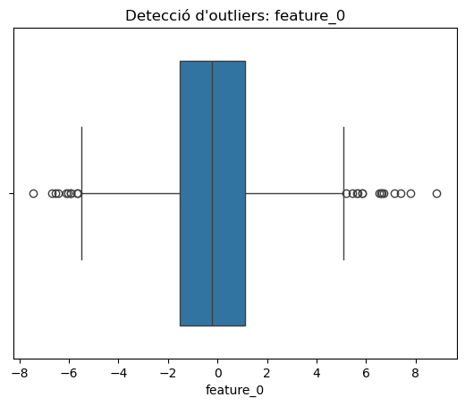

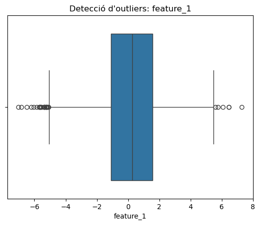

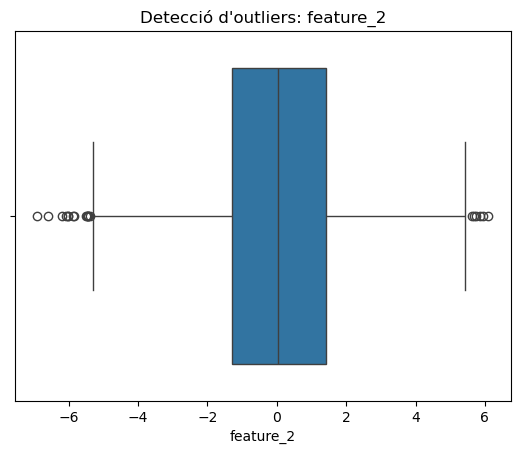

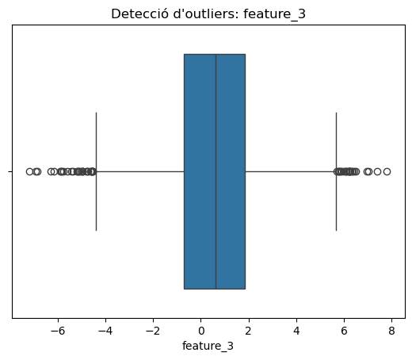

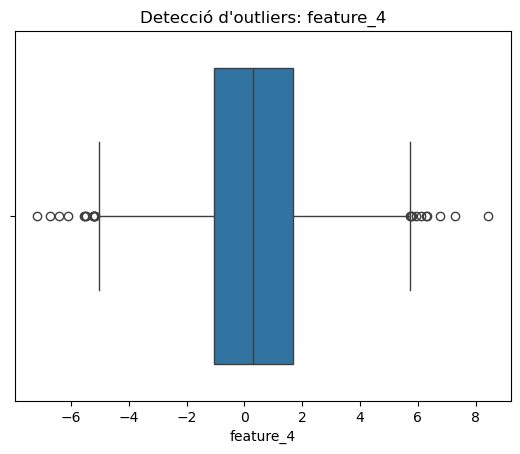

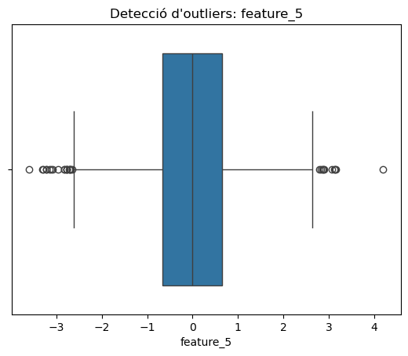

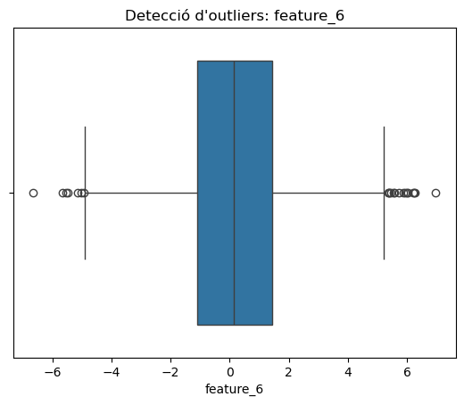

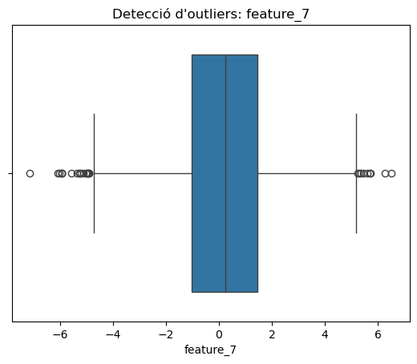

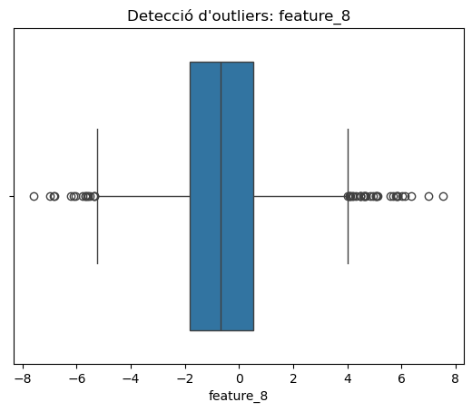

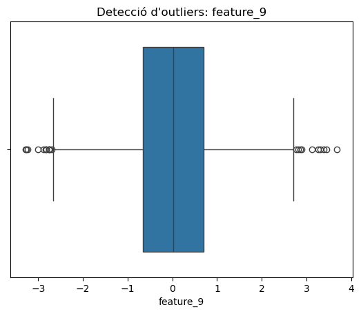

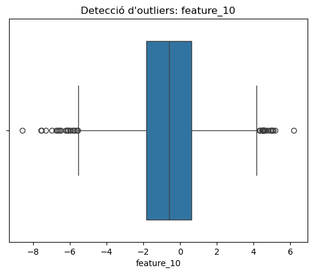

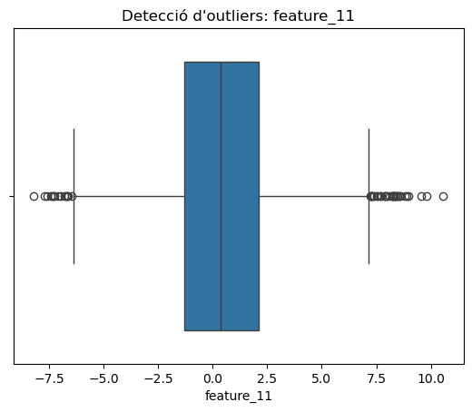

[10 more figures not shown]

```python
for column in df.select_dtypes(include=np.number).columns:
    plt.figure()
    sns.boxplot(data=df, x=column)
    plt.title(f'Detecció d\'outliers: {column}')
    plt.show()
```

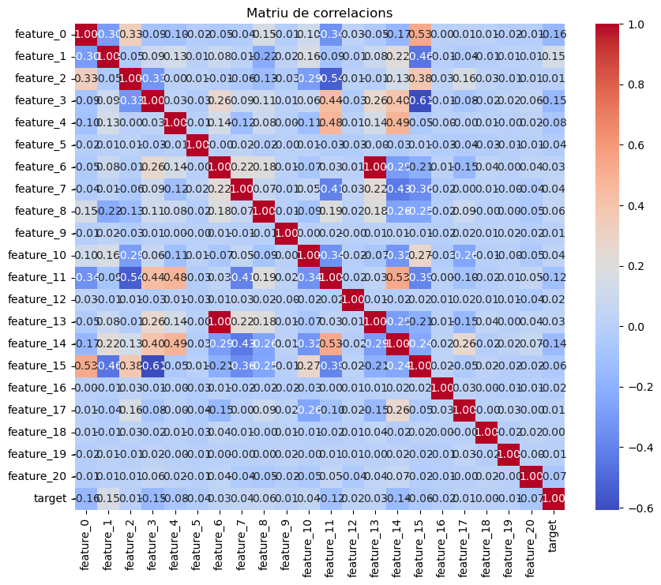

```python
plt.figure(figsize=(10, 8))
correlation_matrix = df.corr(numeric_only=True)
sns.heatmap(correlation_matrix, annot=True, fmt=".2f", cmap="coolwarm")
plt.title("Matriu de correlacions")
plt.show()
```

```python
# Com hi ha moltes variables i el gràfic no queda gaire clar, imprimim la taula per acabar de veure els valors
print("Matriu de correlació completa:")
print(correlation_matrix)
```

```
Matriu de correlació completa:
            feature_0  feature_1  feature_2  feature_3  feature_4  feature_5  \
feature_0    1.000000  -0.295747   0.329755  -0.091548  -0.102547  -0.023121
feature_1   -0.295747   1.000000  -0.047840   0.091493   0.130706   0.006862
feature_2    0.329755  -0.047840   1.000000  -0.325455   0.003956   0.013847
feature_3   -0.091548   0.091493  -0.325455   1.000000   0.029288  -0.029647
feature_4   -0.102547   0.130706   0.003956   0.029288   1.000000  -0.009203
feature_5   -0.023121   0.006862   0.013847  -0.029647  -0.009203   1.000000
feature_6   -0.048365   0.083322  -0.012824   0.260797   0.136969  -0.003927
feature_7   -0.036495   0.014910  -0.061310   0.092254  -0.119039   0.023385
feature_8    0.146147  -0.222503  -0.133162   0.108970   0.076980  -0.022415
feature_9   -0.013395   0.023792  -0.027180   0.008535   0.004866  -0.004867
feature_10   0.102483   0.160353  -0.289210   0.064977  -0.113143   0.013429
feature_11  -0.344454  -0.092948  -0.542683   0.438572   0.476059  -0.028242
feature_12   0.030091  -0.014761   0.012648  -0.026582   0.009774  -0.026580
feature_13  -0.048365   0.083322  -0.012824   0.260797   0.136969  -0.003927
feature_14  -0.167287   0.216542   0.132182   0.402830   0.491075  -0.030623
feature_15   0.532893  -0.455625   0.378670  -0.608395  -0.054833   0.006194
feature_16   0.003881  -0.011032   0.027955  -0.006892  -0.003286  -0.030814
feature_17   0.012390  -0.038952   0.155671  -0.078994  -0.003086  -0.040983
feature_18   0.013600  -0.014764   0.030157  -0.016582   0.011615  -0.028355
feature_19  -0.019087   0.007336  -0.010894   0.021575  -0.001923  -0.008413
feature_20  -0.014735   0.011127   0.012564   0.057412   0.020133  -0.005004
target      -0.157467   0.149550   0.006169  -0.150950  -0.075103  -0.036132

            feature_6  feature_7  feature_8  feature_9  ...  feature_12  \
feature_0   -0.048365  -0.036495   0.146147  -0.013395  ...    0.030091
feature_1    0.083322   0.014910  -0.222503   0.023792  ...   -0.014761
feature_2   -0.012824  -0.061310  -0.133162  -0.027180  ...    0.012648
feature_3    0.260797   0.092254   0.108970   0.008535  ...   -0.026582
feature_4    0.136969  -0.119039   0.076980   0.004866  ...    0.009774
feature_5   -0.003927   0.023385  -0.022415  -0.004867  ...   -0.026580
feature_6    1.000000   0.223511   0.184868   0.010628  ...    0.007249
feature_7    0.223511   1.000000   0.065539  -0.010596  ...    0.031603
feature_8    0.184868   0.065539   1.000000  -0.010857  ...    0.017786
feature_9    0.010628  -0.010596  -0.010857   1.000000  ...   -0.002412
feature_10  -0.072720   0.048930  -0.089161   0.004929  ...   -0.017525
feature_11   0.032289  -0.405193   0.187212   0.016915  ...   -0.017742
feature_12   0.007249   0.031603   0.017786  -0.002412  ...    1.000000
feature_13   1.000000   0.223511   0.184868   0.010628  ...    0.007249
```

[output cut: 43 more lines]

```
feature_9     0.008289    0.016712   -0.017034  0.006719
feature_10   -0.007128   -0.002092   -0.050514  0.035143
feature_11   -0.020755    0.009132    0.052901 -0.118279
feature_12    0.006489    0.010245   -0.044952  0.018998
feature_13    0.036482    0.000583    0.036304  0.030002
feature_14   -0.018069    0.020385    0.072192 -0.144089
feature_15    0.021061   -0.023485   -0.022186 -0.059686
feature_16    0.001202   -0.014014   -0.011242 -0.019510
feature_17   -0.000856    0.033125   -0.000857  0.010047
feature_18    1.000000   -0.022662    0.021347  0.001890
feature_19   -0.022662    1.000000   -0.001871 -0.010549
feature_20    0.021347   -0.001871    1.000000 -0.068571
target        0.001890   -0.010549   -0.068571  1.000000

[22 rows x 22 columns]
```

#### Anàlisi:

El dataset conté 3000 observacions amb 24 variables, de les quals dues són categòriques, 21 numèriques i una és la variable objectiu, target, que sembla tenir 3 etiquetes: 0, 1 i 2. No hi ha cap valor nul. Els valors se situen al voltant del 0, amb algunes excepcions en les que el rang de valors és molt ampli, com la variable feature_14. Les desviacions estàndar es troben al voltant de l'1 i el 2, amb alguna excepció com la variable feature_15 (3.75), indicant unes dades bastant estandarditzades.

En relació a la detecció d'outliers, els boxplots generats indiquen la presència de valors atípics en totes les variables.

Amb la variables target no trobem cap relació siginificativa en aquest primer contacte.

#### Implementació:

3. Aplicar una estratègia de codificació adequada per poder fer servir les variables categòriques en els models. Justifica la teva elecció.

#### Solució:

```python
# En primer lloc, mirem quantes categories tenim a les variables categòriques i la seva corresponent distribució
print("Categories a feature_21:")
print(df['feature_21'].value_counts())

print("\nCategories a feature_22:")
print(df['feature_22'].value_counts())
```

```
Categories a feature_21:
feature_21
CatA_3    750
CatA_2    750
CatA_1    750
CatA_0    750
Name: count, dtype: int64

Categories a feature_22:
feature_22
TypeY    866
TypeZ    815
TypeX    788
TypeW    531
Name: count, dtype: int64
```

```python
# Amb aquesta informació, decidim fer One_Hot encoding (https://www.geeksforgeeks.org/ml-one-hot-encoding/)
df_encoded = pd.get_dummies(df, columns=['feature_21', 'feature_22'], drop_first=True)
print(df_encoded.head())
```

```
   feature_0  feature_1  feature_2  feature_3  feature_4  feature_5  \
0   1.821258   0.910395   0.459186  -1.030711   2.098087   1.921148
1   4.229767  -0.434469   4.726087   0.995552  -3.966756   2.444360
2   0.860488   0.984565   0.042947  -0.365520  -4.947303  -0.574780
3   1.503285   1.769841   1.307190   1.309311   1.169251   0.514564
4  -0.019055  -1.569077  -0.824806   2.347602  -1.001121   0.323452

   feature_6  feature_7  feature_8  feature_9  ...  feature_18  feature_19  \
0  -2.657309  -1.737789  -0.491327   0.782738  ...    0.652387   -0.374180
1  -3.308983   0.848826   0.707739  -1.066422  ...    1.075823    0.181950
2  -2.312484   2.228463  -0.119455   0.893592  ...    0.343067   -0.461241
3   0.847147   0.674670  -3.177230  -0.638325  ...   -0.644789    1.442618
4  -1.198919  -1.544061  -2.337010   0.125649  ...    1.410082   -0.555238

   feature_20  target  feature_21_CatA_1  feature_21_CatA_2  \
0    0.361828       2              False              False
1    3.457472       2              False              False
2   -0.046276       1              False               True
3    1.055786       1              False              False
4    0.688510       0              False               True

   feature_21_CatA_3  feature_22_TypeX  feature_22_TypeY  feature_22_TypeZ
0               True              True             False             False
1               True             False             False              True
2              False             False             False             False
3               True             False             False             False
4              False             False             False              True

[5 rows x 28 columns]
```

#### Anàlisi:

S’han codificat les variables categòriques amb One-Hot Encoding, eliminant una categoria per evitar colinealitat (drop_first=True). D'aquiesta manera, ara el dataset conté només valors numèrics i és apte per a entrenar models. Les noves columnes booleanes indiquen la presència de cada categoria i representen la informació original.

#### Implementació:

4. Analitza la distribució de la variable objectiu (`target`). Visualitza-la (ex., `countplot`) i comenta explícitament sobre el grau de desequilibri entre classes.

#### Solució:

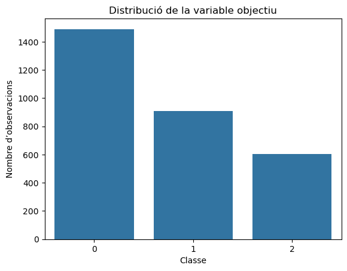

```
target
0    0.497
1    0.302
2    0.201
Name: proportion, dtype: float64
```

```python
sns.countplot(data=df_encoded, x='target')
plt.title("Distribució de la variable objectiu")
plt.xlabel("Classe")
plt.ylabel("Nombre d’observacions")
plt.show()

print(df_encoded['target'].value_counts(normalize=True).round(3))
```

#### Anàlisi:

Es pot veure que la variable objectiu presenta un desequilibri moderat entre les seves classes. Específicament, la classe 0 és la majoritària, amb gairebé la meitat del total d'observaicons. Les classes 1 i 2 estan menys representades, especialment aquesta última.

Aquest desequilibri podria comportar un afavoriment a la classe 0 per part dels models, pel que hauríem de considerar prendre mesures.

#### Implementació:

5. Selecciona una variable numèrica i una variable categòrica que, després de la teva exploració inicial, consideris potencialment influents per a predir la variable objectiu. Justifica la teva elecció.
6. Visualitza la distribució de les variables seleccionades separant-les per classe. Comenta els patrons o diferències que observes.

#### Solució:

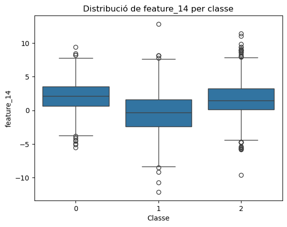

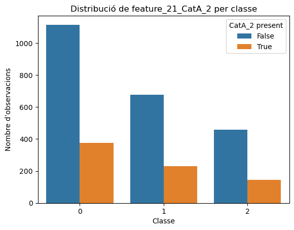

```python
sns.boxplot(data=df_encoded, x='target', y='feature_14')
plt.title("Distribució de feature_14 per classe")
plt.xlabel("Classe")
plt.ylabel("feature_14")
plt.show()

sns.countplot(data=df_encoded, x='target', hue='feature_21_CatA_2')
plt.title("Distribució de feature_21_CatA_2 per classe")
plt.xlabel("Classe")
plt.ylabel("Nombre d’observacions")
plt.legend(title="CatA_2 present")
plt.show()
```

#### Anàlisi:

S'ha decidit escollir la variable feature_14 per tenir una dispersió tan elevada, mentre que la feature_21_CatA_2 s'ha escollit perquè podria estar relacionada amb una classe concreta de la variable objectiu.

#### Implementació:

7. **Anàlisi Crítica:** Basant-te únicament en les troballes de la teva EDA (distribució de classes, tipus de variables, etc.), discuteix els principals desafiaments que anticipes que aquest dataset podria presentar per als algorismes de classificació estàndard. Com creus que el desequilibri observat podria afectar l'avaluació del rendiment?
8. D'acord amb l'anterior, realitza el que consideris necessari per preparar les dades per efectuar el procés de classificació de forma adequada. Recorda prendre les mesures necessàries per evitar biaixos, sobreajustament, fuga de dades, etc. Justifica cadascuna de les decisions preses.

#### Solució:

```python
X = df_encoded.drop("target", axis=1)
y = df_encoded["target"]

X_train, X_test, y_train, y_test = train_test_split(
    X, y, test_size=0.2, stratify=y, random_state=42
)
```

#### Anàlisi:

El nostre dataset presenta classes de la variable target desequilibrades, amb una majoria pertanyent a a classe 0 (49.7%). Això podria derivar en el model afavorint aquesta classe i minimitzant el rendiment de la resta, 1 i 2.

Ens trobem amb outliers a totes les variables, que podrien esbiaixar els models sensibles a valors atípics. A més, tenim una combinació de dades numèriques i categòriques, que ens podrien ocasionar alguns problemes, com overfitting.

En aquest primer anàlisi no s'han trobat relacions significatives entre les variables i la variable objectiu. Això indicaria que s'hauran d'utilitzar mètodes per trobar relacions no lineals, per exemple.

Per a preparar les dades, a banda de la codificació que ja hem realitzat, hem fet una separació de dades d'entrenament i de test. Si fos necessària alguna preparació més, es faria segons el model a utilitzar.

- A posteriori, gairebé a l'acabar, he vist al fòrum que s'havien de treure aquelles variables clarament irrellevants. Jo això no havia considerat fer-ho perquè, primer, no estava segura de tenir evidències suficients per treure-les, i segon, com a algun exercici es demanava de si algun model era adequat tot i les variables sorolloses, vaig arribar a la conclusió que no s'havien de treure. Espero que no condicioni molt el meu anàlisi.

### 1.2. Entrenament i Avaluació de Models Base (0.5 punts)

#### Implementació:

1. Entrena amb el conjunt de dades d'entrenament i valida amb el conjunt de dades de validació els següents models base (Guarda les prediccions per al seu ús més endavant):
   - Regressió Logística (`LogisticRegression`)
   - Arbre de Decisió (`DecisionTreeClassifier`)
   - K veïns més propers (`KNeighborsClassifier`)
   - Classificador Naive Bayes (`GaussianNB`)
2. Per a cada model, reporta les següents mètriques obtingudes de la validació: Precision macro / recall macro / F1 macro (mitjana simple entre classes), Precision weighted / F1 weighted (mitjana ponderada segons el nombre de mostres per classe), F1 micro (mètrica total). Mostra també la matriu de confusió.
3. **Anàlisi Crítica:** Estableix aquests resultats com la teva línia base (baseline). Quina de les mètriques F1 (macro o weighted) consideres més informativa per avaluar el rendiment en aquest dataset específic i per què? Justifica la teva resposta relacionant-la amb el desequilibri de classes observat a la teva EDA. Comenta breument el rendiment d'aquests models base, parant especial atenció a com funcionen per a les classes minoritàries (observa les teves matrius de confusió).

#### Solució:

```
Regressió logística:
              precision    recall  f1-score   support

           0      0.782     0.577     0.664       298
           1      0.589     0.713     0.645       181
           2      0.422     0.562     0.482       121

    accuracy                          0.615       600
   macro avg      0.598     0.617     0.597       600
weighted avg      0.651     0.615     0.622       600
```

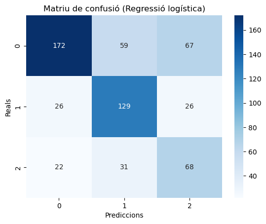

```python
# Regressió logística
scaler = StandardScaler()
X_train_scaled = scaler.fit_transform(X_train)
X_test_scaled = scaler.transform(X_test)

lr = LogisticRegression(class_weight='balanced', max_iter=1000, random_state=42)
lr.fit(X_train_scaled, y_train)
y_pred_lr = lr.predict(X_test_scaled)

print("Regressió logística:")
print(classification_report(y_test, y_pred_lr, digits=3))

cm_lr = confusion_matrix(y_test, y_pred_lr)
sns.heatmap(cm_lr, annot=True, fmt='d', cmap='Blues')
plt.title("Matriu de confusió (Regressió logística)")
plt.xlabel("Prediccions")
plt.ylabel("Reals")
plt.show()
```

```
Arbre de decisió:
              precision    recall  f1-score   support

           0      0.666     0.668     0.667       298
           1      0.633     0.630     0.632       181
           2      0.479     0.479     0.479       121

    accuracy                          0.618       600
   macro avg      0.593     0.592     0.593       600
weighted avg      0.618     0.618     0.618       600
```

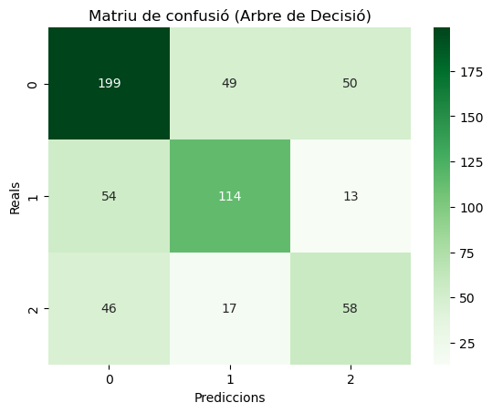

```python
# Arbre de decisió
dt = DecisionTreeClassifier(random_state=42)
dt.fit(X_train, y_train)
y_pred_dt = dt.predict(X_test)

print("Arbre de decisió:")
print(classification_report(y_test, y_pred_dt, digits=3))

cm_dt = confusion_matrix(y_test, y_pred_dt)
sns.heatmap(cm_dt, annot=True, fmt='d', cmap='Greens')
plt.title("Matriu de confusió (Arbre de Decisió)")
plt.xlabel("Prediccions")
plt.ylabel("Reals")
plt.show()
```

```
K Nearest Neighbors:
              precision    recall  f1-score   support

           0      0.730     0.872     0.795       298
           1      0.670     0.685     0.678       181
           2      0.763     0.372     0.500       121

    accuracy                          0.715       600
   macro avg      0.721     0.643     0.658       600
weighted avg      0.719     0.715     0.700       600
```

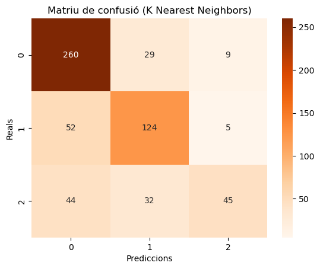

```python
# KNN veïms més propers
knn = KNeighborsClassifier()
knn.fit(X_train_scaled, y_train)
y_pred_knn = knn.predict(X_test_scaled)

print("K Nearest Neighbors:")
print(classification_report(y_test, y_pred_knn, digits=3))

cm_knn = confusion_matrix(y_test, y_pred_knn)
sns.heatmap(cm_knn, annot=True, fmt='d', cmap='Oranges')
plt.title("Matriu de confusió (K Nearest Neighbors)")
plt.xlabel("Prediccions")
plt.ylabel("Reals")
plt.show()
```

```
Naive Bayes:
              precision    recall  f1-score   support

           0      0.746     0.701     0.723       298
           1      0.632     0.663     0.647       181
           2      0.431     0.463     0.446       121

    accuracy                          0.642       600
   macro avg      0.603     0.609     0.605       600
weighted avg      0.648     0.642     0.644       600
```

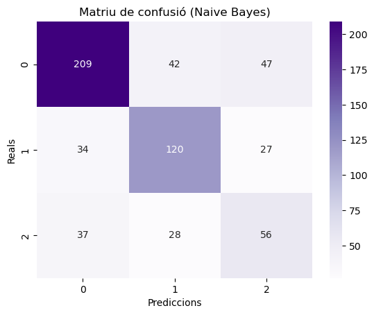

```python
# Classificador Naive Bayes
nb = GaussianNB()
nb.fit(X_train, y_train)
y_pred_nb = nb.predict(X_test)

print("Naive Bayes:")
print(classification_report(y_test, y_pred_nb, digits=3))

cm_nb = confusion_matrix(y_test, y_pred_nb)
sns.heatmap(cm_nb, annot=True, fmt='d', cmap='Purples')
plt.title("Matriu de confusió (Naive Bayes)")
plt.xlabel("Prediccions")
plt.ylabel("Reals")
plt.show()
```

#### Anàlisi:

La classe que més errors dona és la 2, coincidint en que és la més minoritària. No s'ha aconseguit predir fiablement per cap model.

En general, el model que millor rendiemnt ha obtingut és el de KNN veÏns més propers, però tot i així la classe 2 es veu amb molts errors (recall = 0.372).

### 1.3. Combinació paral·lela de classificadors de base similar: Bagging (1 punt)

#### Implementació:

1. Implementa `RandomForestClassifier`.
2. Realitza una cerca i ajust (tuning) d'hiperparàmetres clau (n_estimators, max_depth, max_features) utilitzant validació creuada (ex., GridSearchCV o RandomizedSearchCV amb 5-CV). Defineix un rang de cerca raonable per a cada hiperparàmetre i fes servir la mètrica F1 que vas justificar com a més informativa en el punt anterior per a l'optimització.
3. Reporta els millors hiperparàmetres trobats i l'score de validació creuada obtingut amb ells.

#### Solució:

```python
param_grid = {
    'n_estimators': [50, 100, 200],
    'max_depth': [None, 5, 10, 20],
    'max_features': ['sqrt', 'log2', None]
    }

rf = RandomForestClassifier(random_state=42)

grid_search = GridSearchCV(
    estimator=rf,
    param_grid=param_grid,
    scoring='f1_macro',
    cv=5,
    n_jobs=-1,
    verbose=1
)

grid_search.fit(X_train, y_train)

print("Millors hiperparàmetres trobats:")
print(grid_search.best_params_)

print(f"\nMillor F1 macro (validació creuada): {grid_search.best_score_:.3f}")
```

```
Fitting 5 folds for each of 36 candidates, totalling 180 fits
Millors hiperparàmetres trobats:
{'max_depth': 20, 'max_features': 'sqrt', 'n_estimators': 200}

Millor F1 macro (validació creuada): 0.745
```

#### Anàlisi:

Aquesta puntuació representa una millora clara respecte als models base, especialment en el rendiment global entre classes. Ara que tenim els hiperparàmetres òptims, podem entrenar el model final i validar-lo sobre el conjunt de test.

#### Implementació:

4. Valida (amb el conjunt de dades de validació) el model Random Forest final (entrenat amb els millors hiperparàmetres sobre tot el conjunt d'entrenament).
5. Mostra un gràfic de la importància de les característiques (feature_importance_) del model final.
6. **Anàlisi Crítica:** Compara el rendiment del teu Random Forest optimitzat amb els models base (refereix-te als valors específics de les mètriques que vas obtenir). Va aconseguir RF una millora substancial, especialment en les classes minoritàries? Analitza el teu gràfic d'importància de característiques: Quines variables semblen ser les més rellevants segons RF? Té sentit aquest resultat considerant que el dataset és sintètic i es va dissenyar amb variables informatives, redundants i irrellevants? Identifica RF algunes de les variables categòriques o d'interacció que vam afegir com a importants?

#### Solució:

```
Rendiment del Random Forest optimitzat:
              precision    recall  f1-score   support

           0      0.770     0.919     0.838       298
           1      0.764     0.807     0.785       181
           2      0.887     0.388     0.540       121

    accuracy                          0.778       600
   macro avg      0.807     0.705     0.721       600
weighted avg      0.792     0.778     0.762       600
```

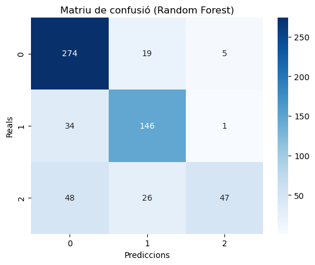

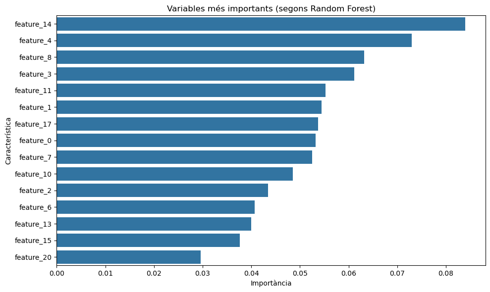

```python
rf_final = RandomForestClassifier(
    n_estimators=200,
    max_depth=20,
    max_features='sqrt',
    random_state=42
)

rf_final.fit(X_train, y_train)
y_pred_rf = rf_final.predict(X_test)

print("Rendiment del Random Forest optimitzat:")
print(classification_report(y_test, y_pred_rf, digits=3))

cm_rf = confusion_matrix(y_test, y_pred_rf)
sns.heatmap(cm_rf, annot=True, fmt='d', cmap='Blues')
plt.title("Matriu de confusió (Random Forest)")
plt.xlabel("Prediccions")
plt.ylabel("Reals")
plt.show()

importances = rf_final.feature_importances_
feature_names = X_train.columns

feat_imp = pd.Series(importances, index=feature_names).sort_values(ascending=False)

plt.figure(figsize=(10, 6))
sns.barplot(x=feat_imp[:15], y=feat_imp.index[:15])
plt.title("Variables més importants (segons Random Forest)")
plt.xlabel("Importància")
plt.ylabel("Característica")
plt.tight_layout()
plt.show()
```

#### Anàlisi:

En quant a les característiques, indica que les variables feature_14, feature_4 i feature_8 són les més importasnts, coincidint la primera variable amb les observacions inicials de l'EDA.

S'observa que el model no troba rellevants les variables menys informatives, coincidint amb el fet de dataset sintètic creat tant amb variables sorolloses i redundants com amb realment informatives.

En el gràfic noapareixen les vasriables categòriques, suggerint que aquestes no tenen tant potencial predictiu com les numèriques.

### 1.4. Combinació paral·lela de classificadors de base similar: Boosting (1 punt)

#### Implementació:

1. Implementa `GradientBoostingClassifier`.
2. Realitza una cerca i ajust (tuning) d'hiperparàmetres clau utilitzant validació creuada. Defineix un rang de cerca raonable per a cada hiperparàmetre i fes servir la mètrica F1 seleccionada.
3. Reporta els millors hiperparàmetres trobats i l'score de validació creuada obtingut amb ells.

#### Solució:

```python
param_grid = {
    'n_estimators': [50, 100, 200],
    'learning_rate': [0.01, 0.1, 0.2],
    'max_depth': [3, 5, 10]
}

gb = GradientBoostingClassifier(random_state=42)

grid_search_gb = GridSearchCV(
    estimator=gb,
    param_grid=param_grid,
    scoring='f1_macro',
    cv=5,
    n_jobs=-1,
    verbose=1
)

grid_search_gb.fit(X_train, y_train)

print("Millors hiperparàmetres trobats (Gradient Boosting):")
print(grid_search_gb.best_params_)

print(f"\nMillor F1 macro (validació creuada): {grid_search_gb.best_score_:.3f}")
```

```
Fitting 5 folds for each of 27 candidates, totalling 135 fits
Millors hiperparàmetres trobats (Gradient Boosting):
{'learning_rate': 0.1, 'max_depth': 10, 'n_estimators': 200}

Millor F1 macro (validació creuada): 0.780
```

#### Anàlisi:

Aquest resultat mostra una millora clara respecte als models base i també supera lleugerament el Random Forest optimitzat (que tenia millor F1 macro = 0.745). És una bona base per validar el model i analitzar la seva robustesa en les següents fases.

#### Implementació:

4. Valida (amb el conjunt de dades de validació) el model final.
5. Mostra un gràfic de la importància de les característiques d'aquest model.
6. **Anàlisi Crítica:** Compara el rendiment del teu Gradient Boosting optimitzat amb els models anteriors. Va aconseguir una millora substancial, especialment en les classes minoritàries? Analitza el teu gràfic d'importància de característiques: Existeixen diferències notables en el rànquing o en les variables considerades més importants pels models boosting en comparació amb Random Forest

#### Solució:

```
Rendiment del Gradient Boosting optimitzat:
              precision    recall  f1-score   support

           0      0.823     0.919     0.868       298
           1      0.788     0.840     0.813       181
           2      0.851     0.521     0.646       121

    accuracy                          0.815       600
   macro avg      0.821     0.760     0.776       600
weighted avg      0.818     0.815     0.807       600
```

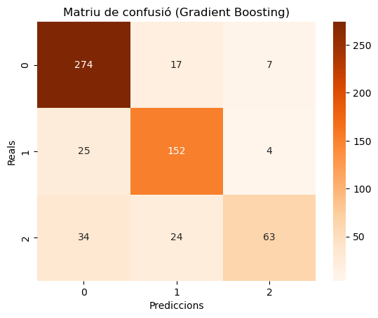

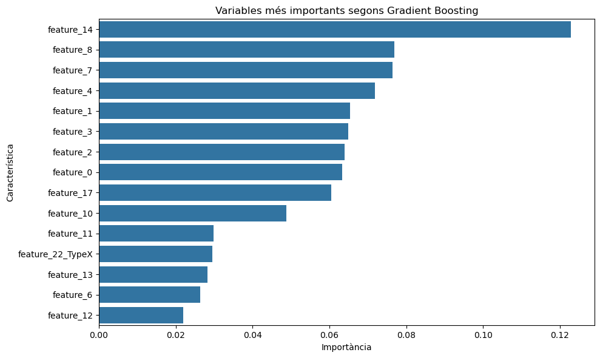

```python
gb_final = GradientBoostingClassifier(
    n_estimators=200,
    learning_rate=0.1,
    max_depth=10,
    random_state=42
)

gb_final.fit(X_train, y_train)
y_pred_gb = gb_final.predict(X_test)

print("Rendiment del Gradient Boosting optimitzat:")
print(classification_report(y_test, y_pred_gb, digits=3))

cm_gb = confusion_matrix(y_test, y_pred_gb)
sns.heatmap(cm_gb, annot=True, fmt='d', cmap='Oranges')
plt.title("Matriu de confusió (Gradient Boosting)")
plt.xlabel("Prediccions")
plt.ylabel("Reals")
plt.show()

importances_gb = gb_final.feature_importances_
feature_names = X_train.columns

feat_imp_gb = pd.Series(importances_gb, index=feature_names).sort_values(ascending=False)

plt.figure(figsize=(10, 6))
sns.barplot(x=feat_imp_gb[:15], y=feat_imp_gb.index[:15])
plt.title("Variables més importants segons Gradient Boosting")
plt.xlabel("Importància")
plt.ylabel("Característica")
plt.tight_layout()
plt.show()
```

#### Anàlisi:

En relació a la importància de les variables, de nou veiem feature_14, feature_8 i feature_4 entre les 5 més importants, afegint-se tambñe feature_7 que escala posicions respecte a Random Forest. Tot i així, els dos models són coherents entre sí. En asquest cas, però, el model sí que incloub una variable codificada: feature_22_TypeX. Això podria indicar que podria tenir més sensibilitat per a detectar relacions entre variables numperiques i categòriques.

En general, Gradient Boosting mostra un millor rendiment tant general com en classes minoritàries.

### 1.5. Combinació seqüencial de classificadors de base diferent: Stacking (1 punt)

#### Implementació:

1. Implementa `StackingClassifier`.
2. Utilitza els models base implementats a la secció 1.2 Creus que aquesta combinació de models és diversa i adequada per a Stacking?
3. Tria un meta-classificador. Pots optar per fer servir els hiperparàmetres per defecte o realitzar un petit ajust si ho consideres necessari.
4. Valida el `StackingClassifier` complet fent servir les dades de validació amb la mètrica F1 seleccionada. Reporta l'score.
5. **Anàlisi Crítica:** Compara el rendiment del teu model de Stacking amb el millor resultat que vas obtenir d'un ensemble individual (RF o Boosting) en els passos anteriors. Va aportar Stacking una millora significativa del rendiment en aquest dataset? Explica breument com creus que el meta-classificador està utilitzant les prediccions dels teus base learners escollits.

#### Solució:

```
F1 macro (Stacking): 0.713

Informe de classificació:
              precision    recall  f1-score   support

           0      0.783     0.846     0.813       298
           1      0.720     0.768     0.743       181
           2      0.706     0.496     0.583       121

    accuracy                          0.752       600
   macro avg      0.736     0.703     0.713       600
weighted avg      0.748     0.752     0.745       600
```

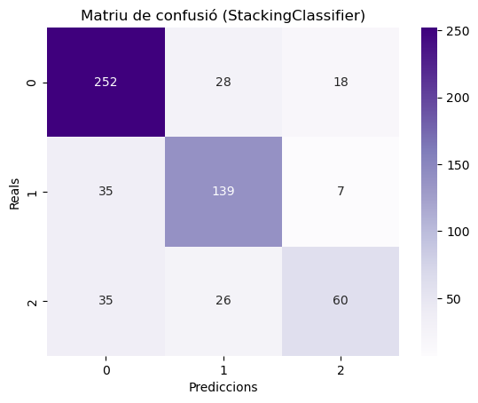

```python
scaler = StandardScaler()
X_train_scaled = scaler.fit_transform(X_train)
X_test_scaled = scaler.transform(X_test)

base_learners = [
    ('logreg', LogisticRegression(max_iter=1000, class_weight='balanced', random_state=42)),
    ('tree', DecisionTreeClassifier(random_state=42)),
    ('knn', KNeighborsClassifier()),
    ('nb', GaussianNB())
]

meta_model = LogisticRegression(max_iter=1000, random_state=42)

stacking_clf = StackingClassifier(
    estimators=base_learners,
    final_estimator=meta_model,
    cv=5,
    passthrough=False,
    n_jobs=-1
)

stacking_clf.fit(X_train_scaled, y_train)
y_pred_stack = stacking_clf.predict(X_test_scaled)

f1_macro_stack = f1_score(y_test, y_pred_stack, average='macro')
print(f"F1 macro (Stacking): {f1_macro_stack:.3f}")

print("\nInforme de classificació:")
print(classification_report(y_test, y_pred_stack, digits=3))

cm_stack = confusion_matrix(y_test, y_pred_stack)
sns.heatmap(cm_stack, annot=True, fmt='d', cmap='Purples')
plt.title("Matriu de confusió (StackingClassifier)")
plt.xlabel("Prediccions")
plt.ylabel("Reals")
plt.show()
```

#### Anàlisi:

En comparació amb el Gradient Boosting, el model de Stacking ha mostrat un rendiment lleugerament inferior en totes les mètriques principals, especialment en la F1 macro (0.713 vs. 0.776). Tot i millorar els resultats dels models base utilitzats individualment, no ha aconseguit superar els millors ensembles (RF i GB). El rendiment per a les classes minoritàries, com la classe 2, ha estat moderat (F1 = 0.583), però inferior al Gradient Boosting (F1 = 0.646).

Pel que fa al comportament general del model, el meta-classificador de regressió logística ha combinat les prediccions dels models base amb una certa eficàcia, aprofitant la diversitat. Tot i així, sembla que les limitacions dels base learners han condicionat el límit màxim de rendiment del model final.

En conjunt, Stacking ha aportat una millora respecte als models individuals, però no ha assolit el nivell d’eficàcia dels millors ensembles específics. Això suggereix que, en aquest cas, el Gradient Boosting continua sent el model més potent i fiable per al dataset analitzat.

### 1.6. Combinació seqüencial de classificadors de base diferent: Cascading (1 punt)

#### Implementació:

1. Combina en cascada els models base implementats a la secció 1.2. Tingues en compte la definició presentada en el document "Combinació de models - PID_00296757, Jordi Casas Roma i Julià Minguillón Alfonso" que es troba als recursos de l'assignatura. Utilitza les prediccions obtingudes a la secció 1.2 Creus que aquesta combinació de models és diversa i adequada per a Cascading?
2. Tria un meta-classificador. Pots optar per fer servir els hiperparàmetres per defecte o realitzar un petit ajust si ho consideres necessari.
3. Valida el teu classificador en cascada complet fent servir les dades de validació amb la mètrica F1 seleccionada. Reporta l'score.
4. **Anàlisi Crítica:** Compara el rendiment del teu model en cascada amb el millor resultat obtingut en els passos anteriors. Va aportar Cascading una millora significativa del rendiment en aquest dataset? Vas observar algun avantatge en termes d'eficiència computacional?

#### Solució:

```
F1 macro (Cascading): 0.593

Informe de classificació:
              precision    recall  f1-score   support

           0      0.666     0.668     0.667       298
           1      0.633     0.630     0.632       181
           2      0.479     0.479     0.479       121

    accuracy                          0.618       600
   macro avg      0.593     0.592     0.593       600
weighted avg      0.618     0.618     0.618       600
```

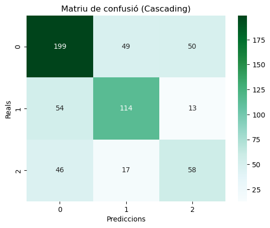

```python
scaler = StandardScaler()
X_train_scaled = scaler.fit_transform(X_train)
X_test_scaled = scaler.transform(X_test)

models_base = {
    'logreg': LogisticRegression(class_weight='balanced', max_iter=1000, random_state=42),
    'tree': DecisionTreeClassifier(random_state=42),
    'knn': KNeighborsClassifier(),
    'nb': GaussianNB()
}

X_train_preds = []
X_test_preds = []

for name, model in models_base.items():
    if name in ['logreg', 'knn']:
        model.fit(X_train_scaled, y_train)
        X_train_pred = model.predict(X_train_scaled)
        X_test_pred = model.predict(X_test_scaled)
    else:
        model.fit(X_train, y_train)
        X_train_pred = model.predict(X_train)
        X_test_pred = model.predict(X_test)
        X_train_preds.append(X_train_pred.reshape(-1, 1))
        X_test_preds.append(X_test_pred.reshape(-1, 1))

X_train_cascade = np.hstack([X_train_scaled] + X_train_preds)
X_test_cascade = np.hstack([X_test_scaled] + X_test_preds)

meta_model = LogisticRegression(max_iter=1000, random_state=42)
meta_model.fit(X_train_cascade, y_train)
y_pred_cascade = meta_model.predict(X_test_cascade)

f1_macro_cascade = f1_score(y_test, y_pred_cascade, average='macro')
print(f"F1 macro (Cascading): {f1_macro_cascade:.3f}")
print("\nInforme de classificació:")
print(classification_report(y_test, y_pred_cascade, digits=3))

cm_cascade = confusion_matrix(y_test, y_pred_cascade)
sns.heatmap(cm_cascade, annot=True, fmt='d', cmap='BuGn')
plt.title("Matriu de confusió (Cascading)")
plt.xlabel("Prediccions")
plt.ylabel("Reals")
plt.show()
```

#### Anàlisi:

En comparació amb el Gradient Boosting i el Random Forest, el model en cascada ha obtingut un rendiment clarament inferior, amb un F1 macro de 0.593, molt proper als models base però lluny del millor (Boosting amb 0.776). Això ens indica que, en aquest cas, la incorporació de les prediccions parcials no ha aportat informació addicional suficient per a millorar la classificació.

Pel que fa a la classe minoritària (classe 2), el model presenta una F1 de 0.479, el mateix valor que va assolir el Decision Tree individualment. Això recolza la idea que el cascading no ha superat les limitacions dels classificadors base.

Tot i que el cascading aprofita una combinació d’enfocaments, el seu impacte final és limitat, probablement per la baixa capacitat dels models base d’aportar una informació prou diferenciada.

En termes d’eficiència computacional, el model sí que és molt ràpid d’entrenar, ja que només implica una passada per cada model base i una fase final de classificació. Tot i això, aquest avantatge no compensa la pèrdua de rendiment predictiu, especialment en el context de dades desequilibrades com les nmostres.

#### Implementació:

5. Dissenya una estructura diferent de classificadors en cascada (ex., classificadors ràpids a la primera etapa per a descartar/classificar instàncies fàcils, i un de més complex a la segona per a les difícils).
6. **Anàlisi Crítica:** Compara el rendiment d'aquest nou model en cascada amb els resultats obtinguts en els passos anteriors. Vas observar algun avantatge en rendiment i/o eficiència computacional?

#### Solució:

```
F1 macro (Cascading 2 etapes): 0.744

Informe de classificació:
              precision    recall  f1-score   support

           0      0.814     0.879     0.845       298
           1      0.737     0.790     0.763       181
           2      0.762     0.529     0.624       121

    accuracy                          0.782       600
   macro avg      0.771     0.733     0.744       600
weighted avg      0.780     0.782     0.776       600
```

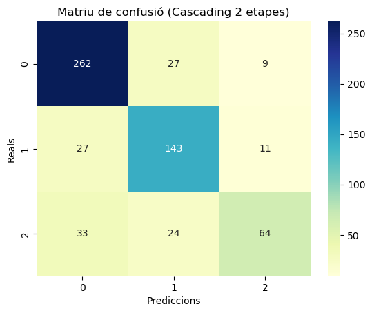

```python
nb_stage1 = GaussianNB()
nb_stage1.fit(X_train, y_train)
probs_nb = nb_stage1.predict_proba(X_test)
preds_nb = np.argmax(probs_nb, axis=1)
confidences = np.max(probs_nb, axis=1)

threshold = 0.8
mask_confident = confidences >= threshold

y_pred_cascade2 = np.empty_like(y_test)

y_pred_cascade2[mask_confident] = preds_nb[mask_confident]

gb_stage2 = GradientBoostingClassifier(
    n_estimators=200, learning_rate=0.1, max_depth=10, random_state=42
)
gb_stage2.fit(X_train, y_train)
y_pred_gb_lowconf = gb_stage2.predict(X_test[~mask_confident])

y_pred_cascade2[~mask_confident] = y_pred_gb_lowconf

f1_macro_cascade2 = f1_score(y_test, y_pred_cascade2, average='macro')
print(f"F1 macro (Cascading 2 etapes): {f1_macro_cascade2:.3f}")
print("\nInforme de classificació:")
print(classification_report(y_test, y_pred_cascade2, digits=3))

cm_cascade2 = confusion_matrix(y_test, y_pred_cascade2)
sns.heatmap(cm_cascade2, annot=True, fmt='d', cmap='YlGnBu')
plt.title("Matriu de confusió (Cascading 2 etapes)")
plt.xlabel("Prediccions")
plt.ylabel("Reals")
plt.show()
```

#### Anàlisi:

En comparació amb els models anteriors, el cascading de dues etapes ha mostrat un rendiment molt competitiu, amb un F1 macro de 0.744, gairebé al nivell del Gradient Boosting (0.776) i superior al Random Forest (0.721) i al Stacking (0.713). A més, ha aconseguit uns bons resultats per a totes les classes, destacant especialment en la classe 2, amb una F1 de 0.624, una millora clara respecte al cascading clàssic (0.479).

En conjunt, es pot dir que aquesta estructura escalonada permet optimitzar el cost computacional mantenint un alt rendiment predictiu.

### 1.7. Comparació Global i Conclusions (1 punt)

#### Implementació:

1. Crea una taula resum que compari clarament el rendiment (Accuracy, F1-macro, F1-weighted) de tots els models implementats (línies base i ensembles). Si és possible i rellevant, afegeix una columna amb el temps d'ajust/entrenament aproximat.
2. **Anàlisi Crítica Final:** Basant-te exclusivament en els resultats numèrics de la teva taula resum, quin paradigma d'ensemble learning (Bagging, Boosting, Stacking, Cascading) va demostrar el millor rendiment global per a aquest problema de classificació, especialment considerant el desequilibri de classes? Justifica la teva elecció referint-te a valors específics de la teva taula.
3. Discuteix els trade-offs que hagis pogut observar (ex., rendiment vs. complexitat del model, rendiment vs. temps d'entrenament/tuning).

**Reflexiona críticament:** Com creus que les diferents complexitats que vam buscar incloure en el dataset (no linealitat, interaccions, soroll, desequilibri, variables irrellevants) van poder influir en el rendiment relatiu dels algorismes que vas provar?

#### Solució:

```python
resultats = {
    'Model': [
        'Regressió Logística',
        'Arbre de Decisió',
        'KNN',
        'Naive Bayes',
        'Random Forest',
        'Gradient Boosting',
        'Stacking',
        'Cascading (clàssic)',
        'Cascading (2 etapes)'
    ],
    'Accuracy': [0.615, 0.618, 0.715, 0.642, 0.778, 0.815, 0.752, 0.618, 0.782],
    'F1 Macro': [0.597, 0.593, 0.658, 0.605, 0.721, 0.776, 0.713, 0.593, 0.744],
    'F1 Weighted': [0.622, 0.618, 0.700, 0.644, 0.762, 0.807, 0.745, 0.618, 0.776],
}

df_resultats = pd.DataFrame(resultats)
df_resultats = df_resultats.sort_values(by='F1 Macro', ascending=False).reset_index(drop=True)
display(df_resultats)
```

|  | Model | Accuracy | F1 Macro | F1 Weighted |
| --- | --- | --- | --- | --- |
| 0 | Gradient Boosting | 0.815 | 0.776 | 0.807 |
| 1 | Cascading (2 etapes) | 0.782 | 0.744 | 0.776 |
| 2 | Random Forest | 0.778 | 0.721 | 0.762 |
| 3 | Stacking | 0.752 | 0.713 | 0.745 |
| 4 | KNN | 0.715 | 0.658 | 0.700 |
| 5 | Naive Bayes | 0.642 | 0.605 | 0.644 |
| 6 | Regressió Logística | 0.615 | 0.597 | 0.622 |
| 7 | Arbre de Decisió | 0.618 | 0.593 | 0.618 |
| 8 | Cascading (clàssic) | 0.618 | 0.593 | 0.618 |

#### Anàlisi:

Basant-nos exclusivament en els valors numèrics de la taula resum, el model Gradient Boosting, ha estat el que ha assolit el millor rendiment global amb la mètrica F1 macro més alta (0.776), una precisió de 0.815 i una F1 weighted de 0.807.

Aquest rendiment destaca especialment per la seva consistència entre totes les classes, incloses les minoritàries. El Gradient Boosting ha estat l’únic model capaç d’obtenir F1 > 0.8 en les classes majoritàries i mantenir un rendiment moderat però robust en la classe 2, la més desequilibrada.

Altres paradigmes com Stacking (F1 macro = 0.713) i Cascading (2 etapes, F1 macro = 0.744) han mostrat resultats competitius, però no han superat el Boosting en cap mètrica clau. El Bagging, representat pel Random Forest (F1 macro = 0.721), tot i oferir un bon balanç, s’ha quedat lleugerament per sota.

En relació a les complexitats incloses en el dataset, trobo que han condicionat el tipus de model que ha funcionat millor, afavorint uns per sobre d'altres.

## 2. Combinació de models de Regressió (4 punts)

### 2.1. Càrrega i Anàlisi Exploratòria de Dades -EDA- (0.5 punts)

#### Implementació:

1. Carrega el dataset `dataset_regresion_pec4.csv`.
2. Realitza una exploració inicial: revisa la informació general, identifica els tipus de dades, valors mancants, valors atípics, anàlisi de correlacions, etc.

#### Solució:

```python
reg_data = pd.read_csv('dataset_regresion_pec4.csv')
```

```python
print("Informació general:")
print(reg_data.info())
```

```
Informació general:
<class 'pandas.core.frame.DataFrame'>
RangeIndex: 3000 entries, 0 to 2999
Data columns (total 24 columns):
 #   Column      Non-Null Count  Dtype
---  ------      --------------  -----
 0   feature_0   3000 non-null   float64
 1   feature_1   3000 non-null   float64
 2   feature_2   3000 non-null   float64
 3   feature_3   3000 non-null   float64
 4   feature_4   3000 non-null   float64
 5   feature_5   3000 non-null   float64
 6   feature_6   3000 non-null   float64
 7   feature_7   3000 non-null   float64
 8   feature_8   3000 non-null   float64
```

[output cut: 18 more lines]

```python
print("Estadístiques descriptives:")
display(reg_data.describe())
```

```
Estadístiques descriptives:
```

|  | feature_0 | feature_1 | feature_2 | feature_3 | feature_4 | feature_5 | feature_6 | feature_7 | feature_8 | feature_9 | ... | feature_13 | feature_14 | feature_15 | feature_16 | feature_17 | feature_18 | feature_19 | feature_20 | feature_21 | target |
| --- | --- | --- | --- | --- | --- | --- | --- | --- | --- | --- | --- | --- | --- | --- | --- | --- | --- | --- | --- | --- | --- |
| count | 3000.000000 | 3000.000000 | 3000.000000 | 3000.000000 | 3000.000000 | 3000.000000 | 3000.000000 | 3000.000000 | 3000.000000 | 3000.000000 | ... | 3000.000000 | 3000.000000 | 3000.000000 | 3000.000000 | 3000.000000 | 3000.000000 | 3000.000000 | 3000.000000 | 3000.000000 | 3000.000000 |
| mean | 5.021543 | 5.051891 | 5.005936 | 5.028777 | 5.068402 | 4.975929 | 4.906712 | 5.060034 | 5.070173 | 5.023456 | ... | 5.011472 | 5.072240 | 5.046688 | 5.024344 | 4.935614 | 5.008225 | 5.010288 | 8.557635 | 2.504973 | 0.100467 |
| std | 2.891599 | 2.936979 | 2.921469 | 2.935711 | 2.917497 | 2.925945 | 2.844701 | 2.979116 | 2.850197 | 3.002585 | ... | 2.888933 | 2.989869 | 2.931291 | 2.882584 | 2.944228 | 2.929464 | 2.905058 | 3.505216 | 1.463356 | 6.432188 |
| min | 0.005197 | 0.004927 | 0.002975 | 0.000678 | 0.001883 | 0.001148 | 0.004678 | 0.006679 | 0.004052 | 0.005569 | ... | 0.001792 | 0.000819 | 0.000922 | 0.001687 | 0.000837 | 0.005082 | 0.003829 | 0.116825 | -0.196887 | -36.804534 |
| 25% | 2.545296 | 2.463100 | 2.434390 | 2.451320 | 2.522927 | 2.419324 | 2.446370 | 2.605828 | 2.656224 | 2.411644 | ... | 2.474519 | 2.632361 | 2.573185 | 2.497222 | 2.406686 | 2.493048 | 2.491462 | 5.988610 | 1.214951 | -4.225614 |
| 50% | 4.999351 | 5.165146 | 5.026991 | 5.114239 | 5.100698 | 4.925344 | 4.900717 | 5.006263 | 5.085142 | 5.041558 | ... | 4.999278 | 5.099452 | 5.064297 | 5.054047 | 4.920872 | 4.937157 | 5.005381 | 8.542005 | 2.498453 | -0.409635 |
| 75% | 7.508207 | 7.564666 | 7.540874 | 7.483389 | 7.636131 | 7.523966 | 7.277698 | 7.557672 | 7.524374 | 7.553653 | ... | 7.481007 | 7.537170 | 7.545753 | 7.489901 | 7.390226 | 7.495196 | 7.450939 | 11.108943 | 3.764838 | 4.114815 |
| max | 24.474674 | 25.458101 | 22.781758 | 31.095439 | 20.399496 | 16.663653 | 9.996865 | 34.746600 | 11.775329 | 40.760056 | ... | 22.973850 | 41.481948 | 32.590963 | 10.993988 | 40.817264 | 25.915744 | 26.815894 | 31.192888 | 11.451153 | 49.389081 |

8 rows × 23 columns

```python
print("Valors mancants per columna:")
print(reg_data.isnull().sum())
```

```
Valors mancants per columna:
feature_0     0
feature_1     0
feature_2     0
feature_3     0
feature_4     0
feature_5     0
feature_6     0
feature_7     0
feature_8     0
feature_9     0
feature_10    0
feature_11    0
feature_12    0
feature_13    0
feature_14    0
feature_15    0
feature_16    0
feature_17    0
feature_18    0
feature_19    0
feature_20    0
feature_21    0
feature_22    0
target        0
dtype: int64
```

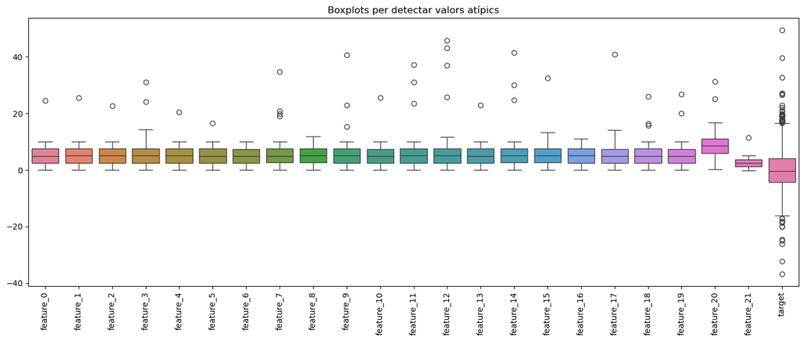

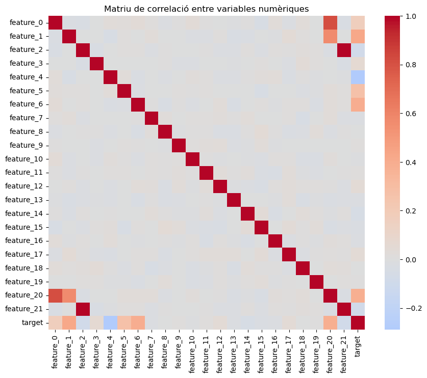

```python
plt.figure(figsize=(14, 6))
sns.boxplot(data=reg_data.select_dtypes(include='number'))
plt.title("Boxplots per detectar valors atípics")
plt.xticks(rotation=90)
plt.tight_layout()
plt.show()

corr = reg_data.corr(numeric_only=True)
plt.figure(figsize=(10, 8))
sns.heatmap(corr, annot=False, cmap='coolwarm', center=0)
plt.title("Matriu de correlació entre variables numèriques")
plt.show()
```

```python
print("Matriu de correlació completa:")
print(corr)
```

```
Matriu de correlació completa:
            feature_0  feature_1  feature_2  feature_3  feature_4  feature_5  \
feature_0    1.000000  -0.024631  -0.029641   0.001425   0.032497   0.021052
feature_1   -0.024631   1.000000   0.002467  -0.000631  -0.041337   0.016883
feature_2   -0.029641   0.002467   1.000000  -0.033877  -0.006995   0.009371
feature_3    0.001425  -0.000631  -0.033877   1.000000  -0.002206  -0.001927
feature_4    0.032497  -0.041337  -0.006995  -0.002206   1.000000   0.029705
feature_5    0.021052   0.016883   0.009371  -0.001927   0.029705   1.000000
feature_6    0.034819  -0.002576   0.017269   0.000149  -0.026884  -0.017638
feature_7    0.017657   0.023600  -0.018081  -0.005780  -0.006527  -0.002926
feature_8   -0.014894  -0.000947   0.002984   0.005877  -0.021656  -0.006305
feature_9    0.003851  -0.000025   0.000238  -0.021233  -0.002600   0.008683
feature_10   0.036512  -0.012802  -0.004050  -0.020716   0.018467   0.003852
feature_11   0.004002  -0.014239   0.005172   0.001838   0.011526   0.017072
feature_12   0.000619   0.008291  -0.021262  -0.006522  -0.022251   0.002058
feature_13  -0.007592  -0.027739  -0.020034  -0.008470  -0.014347  -0.003672
feature_14   0.007297  -0.024139   0.011250   0.001192   0.005995  -0.006282
feature_15  -0.041911   0.001162  -0.014429   0.010978   0.022366  -0.038026
feature_16   0.030086  -0.007769   0.013133  -0.007073   0.031151  -0.006863
feature_17  -0.015195   0.045898   0.003736  -0.019227  -0.022922   0.002256
feature_18   0.025616   0.013378   0.022987   0.034964   0.005419  -0.016455
feature_19  -0.004781   0.002007   0.010378   0.008229  -0.007465  -0.007992
feature_20   0.809606   0.566165  -0.022608   0.001977   0.002093   0.028879
feature_21  -0.031549   0.002518   0.997620  -0.037145  -0.007290   0.008770
target       0.165170   0.429382  -0.087345   0.061624  -0.289197   0.265111

            feature_6  feature_7  feature_8  feature_9  ...  feature_13  \
feature_0    0.034819   0.017657  -0.014894   0.003851  ...   -0.007592
feature_1   -0.002576   0.023600  -0.000947  -0.000025  ...   -0.027739
feature_2    0.017269  -0.018081   0.002984   0.000238  ...   -0.020034
feature_3    0.000149  -0.005780   0.005877  -0.021233  ...   -0.008470
feature_4   -0.026884  -0.006527  -0.021656  -0.002600  ...   -0.014347
feature_5   -0.017638  -0.002926  -0.006305   0.008683  ...   -0.003672
feature_6    1.000000   0.006290  -0.030055   0.004543  ...   -0.028654
feature_7    0.006290   1.000000   0.021254  -0.005107  ...    0.004443
feature_8   -0.030055   0.021254   1.000000  -0.008562  ...   -0.023623
feature_9    0.004543  -0.005107  -0.008562   1.000000  ...   -0.018112
feature_10  -0.016605   0.013849   0.003202   0.016538  ...   -0.004850
feature_11  -0.004040   0.011170   0.006029   0.018642  ...    0.003534
feature_12   0.031522   0.021142  -0.027104   0.026188  ...   -0.011481
```

[output cut: 47 more lines]

```
feature_10   -0.024068    0.022403   -0.001805 -0.011184
feature_11   -0.013918   -0.004726    0.004595  0.013354
feature_12    0.009194    0.005663   -0.021920  0.039565
feature_13   -0.012007   -0.022453   -0.019107 -0.019084
feature_14    0.011819   -0.007960    0.012644 -0.052418
feature_15    0.024536   -0.033857   -0.014196 -0.024760
feature_16   -0.010681    0.020967    0.016227 -0.021532
feature_17    0.003008    0.013279    0.003624  0.043243
feature_18   -0.001613    0.029372    0.022699  0.001997
feature_19    1.000000   -0.003058    0.009678  0.004023
feature_20   -0.003058    1.000000   -0.024168  0.388812
feature_21    0.009678   -0.024168    1.000000 -0.087701
target        0.004023    0.388812   -0.087701  1.000000

[23 rows x 23 columns]
```

#### Anàlisi:

Pel que fa a les correlacions, hi ha algunes variables amb relació moderada amb la variable objectiu, com feature_1 (0.43), feature_6 (0.40) i feature_20 (0.39), així com feature_5 (0.27). També s’observen correlacions negatives més petites, com feature_4 (-0.29). Això indica que hi ha relacions lineals significatives en el conjunt i que aquestes podrien tenir pes en els models.

#### Implementació:

3. Aplicar una estratègia de codificació adequada per poder fer servir les variables categòriques en els models. Justifica la teva elecció.

#### Solució:

```python
# Info de https://www.geeksforgeeks.org/ml-one-hot-encoding/
reg_data_encoded = pd.get_dummies(reg_data, columns=['feature_22'], drop_first=True)

print(reg_data_encoded.head())
```

```
   feature_0  feature_1  feature_2  feature_3  feature_4  feature_5  \
0   1.116128   6.691743   9.349368   4.709568   1.547680   5.929364
1   5.387639   4.881082   8.744185   4.711230   8.172760   8.520234
2   0.812016   5.537114   4.829327   7.714664   8.933394   3.406353
3   3.223983   2.787226   3.913597   8.372647   0.931298   1.886093
4   8.098364   3.439891   9.751921   1.590900   7.911253   3.574520

   feature_6  feature_7  feature_8  feature_9  ...  feature_16  feature_17  \
0   5.965084   6.876529   7.302419   4.618961  ...    2.389177    8.389263
1   9.749182   9.122798   8.248635   1.416425  ...    3.837258    1.044314
2   0.373492   1.834917   1.427191   0.925112  ...    9.447170    0.192824
3   5.871562   9.175196   2.118159   1.029306  ...    0.407282    6.443707
4   5.974649   9.812732   2.968866   5.552527  ...    5.600069    0.116236

   feature_18  feature_19  feature_20  feature_21    target  \
0    9.668625    3.867814    5.602655    4.846594  3.106014
1    7.236030    2.584318    8.820014    4.398644  7.092057
2    6.466151    1.570128    4.598168    2.497320 -3.105620
3    5.900566    7.082611    5.066236    1.935365  4.442592
4    6.812317    5.572394   10.703050    4.943327  1.573806

   feature_22_RegCat_1  feature_22_RegCat_2  feature_22_RegCat_3
0                False                 True                False
1                False                False                 True
2                False                False                False
3                 True                False                False
4                 True                False                False

[5 rows x 26 columns]
```

#### Anàlisi:

De nou, s'ha fet servir la codificació One-Hot per codificar la variable categòrica i fer-la "utilitzable" pels models. Es creen noves columnes amb cada categoria i es converteixen en booleans.

#### Implementació:

4. Visualitza la relació entre la variable objectiu i almenys dues variables predictores numèriques i una categòrica (ex., scatter plots, boxplots per categoria).

#### Solució:

[figure not shown]

```python
plt.figure(figsize=(12, 5))
plt.subplot(1, 2, 1)
sns.scatterplot(x='feature_1', y='target', data=reg_data_encoded)
plt.title("Target vs Feature 0")
```

[figure not shown]

```python
plt.subplot(1, 2, 2)
sns.scatterplot(x='feature_20', y='target', data=reg_data_encoded)
plt.title("Target vs Feature 1")
plt.tight_layout()
plt.show()
```

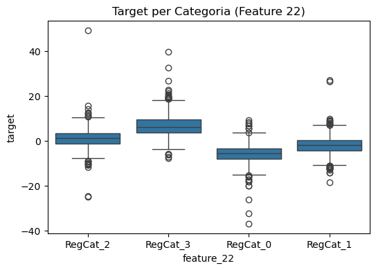

```python
plt.figure(figsize=(6, 4))
sns.boxplot(x='feature_22', y='target', data=reg_data)
plt.title("Target per Categoria (Feature 22)")
plt.show()
```

#### Anàlisi:

A partir dels gràfics, s'observa que la variasble feature_20 mostra una tendència ascendent clara amb target, mentre que la relació amb feature_1 és més difusa, tot i que té una tendència vertical també.

Pel que fa a la variable categòrica feature_22, el boxplot mostra diferències entre categories. Per exemple, RegCat_3 tendeix a tenir valors de target més elevats que RegCat_0, que té una mitjana més baixa i més dispersió. Això ens indica que feature_22 podria aportar informació rellevant en models de regressió.

#### Implementació:

5. **Anàlisi Crítica:** Basant-te en la teva EDA (distribució del target, scatter plots), quines característiques de les dades (ex., no linealitats aparents, valors atípics, possible heteroscedasticitat) podrien suposar un desafiament per a models de regressió lineal simples? Esperaries que els ensembles basats en arbres funcionessin millor aquí? Per què?
6. D'acord amb l'anterior, realitza el que consideris necessari per preparar les dades per efectuar el procés de regressió de forma adequada. Recorda prendre les mesures necessàries per evitar biaixos, sobreajustament, fuga de dades, etc. Justifica cadascuna de les decisions preses.

#### Solució:

```python
# Dividim les dades en entrenament i test per evitar fuga de dades i per facilitar l'entrenament dels models
X = reg_data_encoded.drop(columns=['target'])
y = reg_data_encoded['target']

X_train, X_val, y_train, y_val = train_test_split(X, y, test_size=0.2, random_state=42)
```

#### Anàlisi:

L’anàlisi exploratòria ens mostra que la variable objectiu presenta valors atípics i una distribució asimètrica, amb presència d'outliers en les dues cues. Els scatter plots indiquen que la relació entre algunes variables numèriques i la target no és clarament lineal. A més, s'observa heteroscedasticitat, que podria afectar el rendiment dels models lineals.

Per això, els models basats en arbres, com Random Forest o Gradient Boosting, són bones opcions, ja que no assumeixen linealitat, són resistents als outliers i poden capturar interaccions complexes entre variables de manera natural.

### 2.2. Entrenament i Avaluació de Models Base (0.5 punts)

#### Implementació:

1. Implementa i avalua dos models base utilitzant 5-CV:
   - Regressió Lineal (`LinearRegression`)
   - Arbre de Decisió regresor (`DecisionTreeRegressor`)
2. Reporta les mètriques mitjanes de 5-CV: RMSE (Root Mean Squared Error), MAE (Mean Absolute Error) i R².
3. **Anàlisi Crítica:** Estableix aquests resultats com a línia base. Compara el rendiment d'ambdós models utilitzant els teus valors reportats de R² i RMSE. Quin va funcionar millor? Era això esperable basant-te en la teva anàlisi EDA prèvia sobre possibles no linealitats?.

#### Solució:

```python
lr = LinearRegression()
dt = DecisionTreeRegressor(random_state=42)

cv = KFold(n_splits=5, shuffle=True, random_state=42)

results = {}

def evaluate_model(model, name):
    preds = cross_val_predict(model, X_train, y_train, cv=cv)
    rmse = np.sqrt(mean_squared_error(y_train, preds))
    mae = mean_absolute_error(y_train, preds)
    r2 = r2_score(y_train, preds)
    results[name] = {'RMSE': rmse, 'MAE': mae, 'R2': r2}

evaluate_model(lr, 'Regressió linear')
evaluate_model(dt, 'Arbre de decisió')

pd.DataFrame(results).T
```

|  | RMSE | MAE | R2 |
| --- | --- | --- | --- |
| Regressió linear | 4.313439 | 3.150659 | 0.546818 |
| Arbre de decisió | 5.802442 | 4.418509 | 0.179938 |

#### Anàlisi:

La regressió lineal ha obtingut millors resultats que l’arbre de decisió en totes les mètriques (menor RMSE i MAE, i major R²), indicant que s’ajusta millor a les dades. Tot i que l’EDA m'ha semblat que suggeria possibles no linealitats i outliers, el comportament general sembla prou lineal perquè el model lineal funcioni millor. L’arbre pot haver tingut dificultats per generalitzar, especialment per la presència de soroll o valors extrems.

### 2.3. Combinació paral·lela de regresors de base similar: Bagging o Boosting (1 punt)

#### Implementació:

1. Selecciona i implementa un regresor combinat de base similar (`RandomForestRegressor`, `AdaBoostRegressor`, `GradientBoostingRegressor`, `XGBoost`, `LightGBM`). Justifica l'elecció.
2. Realitza una cerca i ajust (tuning) d'hiperparàmetres clau (n_estimators, max_depth, max_features) utilitzant validació creuada (ex., GridSearchCV o RandomizedSearchCV amb 5-CV). Pots optimitzar per a `neg_root_mean_squared_error` o `r2`.
3. Reporta els millors hiperparàmetres trobats i l'score de validació creuada obtingut amb ells.